# tidymodels vs caret: a new way to setting the models

apopov

Last updated: 30 November, 2020

## Hello world!

Мне говорили, что общение с объектом, которому хочешь понравиться, стоит начинать с шутки или анекдота, потому давайте начнём пару на позитивной ноте и посмотрим на смешную собачку.

[figure not shown]

А поговорим мы сегодня про **tidymodels** - сборник пакетов для машинного обучения, который соблюдает все заповеди tidy (https://www.tidymodels.org/packages/). (автор обоих пакетов - https://github.com/topepo)

## Погодите, а что такое тайди?

Я не придумал лучшего определения, как “некоторые принципы работы с данными и кодом, позволяющие быстрее воспринимать работу”. Подсознательно вы и без меня эти принципы знаете:

- Каждый столбик датасета - переменная;
- Каждая строка датасета - наблюдение;
- Каждая ячейка датасета - значение.

Однако тут отличия не кончаются: также с принципами tidy приходит иная, отличная от классической, манера ведения кода. Вы наверное замечали, что выбрать одну переменную можно как и через `dataset$var`, так и через `select(dataset, var)`? Более подробный пример - на пикче снизу.

[figure not shown]

Такими принципы вывел некто Хадли Уикхем (главный научный сотрудник RStudio, его манифест: https://cran.r-project.org/web/packages/tidyverse/vignettes/manifesto.html):

- Reuse existing data structures.
- Compose simple functions with the pipe.
- Embrace functional programming.
- Design for humans.

## Так, а что там по машинному обучению?

Большинство из вас пользуются пакетами `rpart` или `caret` - универсальными штучками для построения predictive models. Для чего-то изощрённого нужно лазить по другим библиотекам: например, `RandomForest` - для Random Forest, `ROCR` для построения графиков метрик качества моделей, `mboost` для бустинга… Но на изучение всего и жизни не хватит, потому было бы классно заиметь что-то общее, что объединяло бы всё вместе?

И тут на сцену в сияющих доспехах и с короной (на голове) выходит `tidymodels`. Это не пакет, как я и говорил ранее, а сборник (мета-пакет) из 5 других пакетов:

- `rsample` - для разделения и семплинга данных;
- `recipes` - для пре-процессинга;
- `parsnip` - основной пакет для моделирования ваших чудес;
- `workflows` - то, что заставляет работать всё это вместе;
- `yardstick` - оценка эффективности моделей; а также `broom`, `dials` и `tune` - комплемент от создателей сборки.

## Так а в чём разница?

Предлагаю сравнить на практике. Думаю, ирисы всем поднадоели, а как насчёт пингвинов? (https://github.com/allisonhorst/palmerpenguins)

```r
# install.packages("palmerpenguins")
library(palmerpenguins)
library(tidyverse)
library(tidymodels)
library(caret)

data = penguins
summary(data)
data = data %>%
  na.omit()
```

[output not shown]

Вкратце: пингвины-мальчики и пингвины-девочки трёх видов живут на трёх разных островах. Вместо остальной инструкции по датасету (которую вы можете найти по https://towardsdatascience.com/penguins-dataset-overview-iris-alternative-9453bb8c8d95 ) - урок зоологии:

[figure not shown]

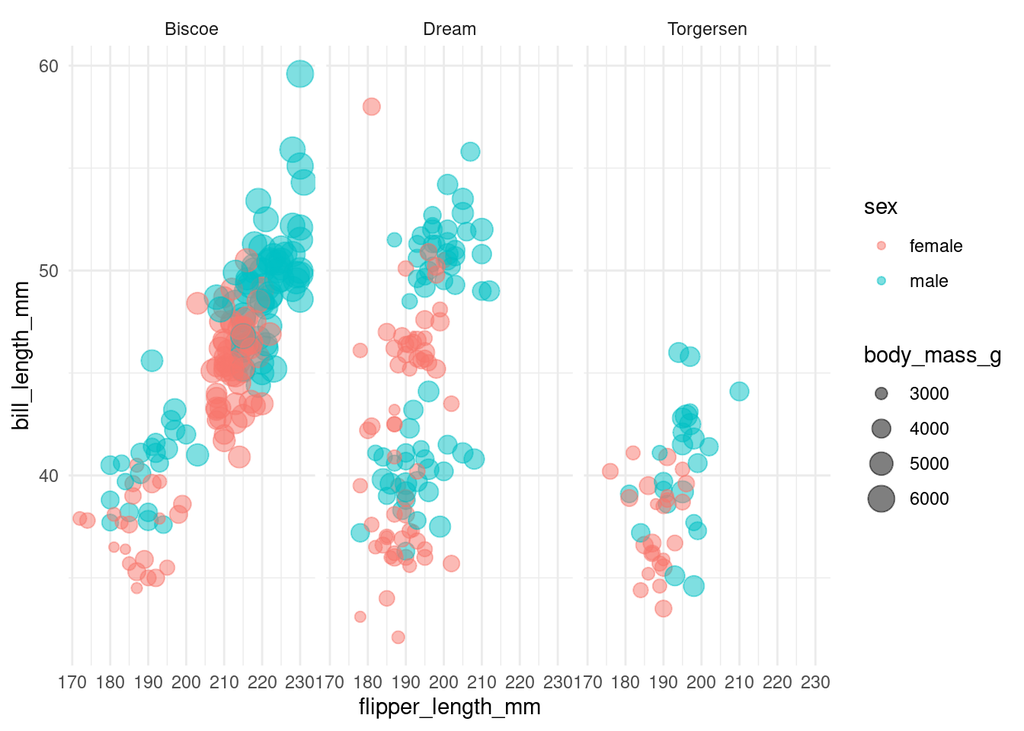

```r
data %>%
  filter(!is.na(sex)) %>%
  ggplot(aes(flipper_length_mm, bill_length_mm, color = sex, size = body_mass_g)) +
  geom_point(alpha = 0.5) +
  facet_grid(cols = vars(island)) +
  theme_minimal()
```

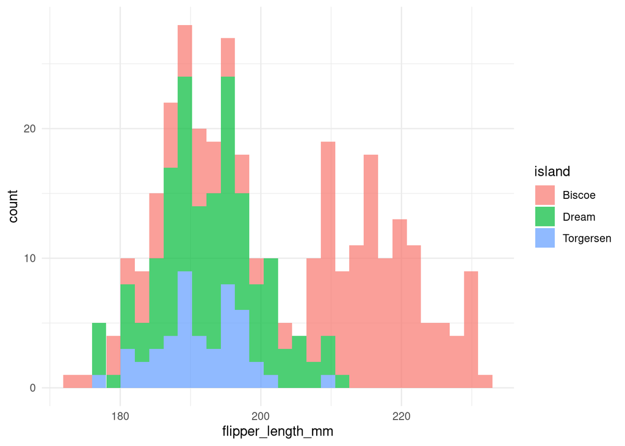

```r
data %>%
  filter(!is.na(sex)) %>%
  ggplot(aes(flipper_length_mm, fill = island, size = body_mass_g)) +
  geom_histogram(alpha = 0.7) +
  theme_minimal()
```

### Начнём с разбиения на выборки

Предсказывать мы будем вид пингвина, параллельно используя как `caret` (в начале будет `c_`), так и `tidymodels` (`t_` соответственно).

```r
set.seed(42)

#caret way

c_sampling = caret::createDataPartition(data$species, p = .8, list = FALSE)
c_train = data[c_sampling,]
c_test = data[-c_sampling,]

#tidy way

t_split = rsample::initial_split(data, prop = 0.8, breaks = 4, strata = species)
t_train = rsample::training(t_split)
t_test = rsample::testing(t_split)

nrow(c_train)
```

```
## [1] 268
```

```r
nrow(t_train)
```

```
## [1] 268
```

Оба метода дали одинаковые результаты в плане объёма, однако разница в синтаксисе - в случае с `caret` мы через диапазоны прописывали, что 80% отобранных от датасета данных должны или не должны войти в выборку. В случае с `tidymodels` (`rsample`) это всё делается через соответствующие ф-ции.

По дополнительным аргументам: обе умеют в кросс-валидацию (см.ниже) и сплиты нумерик переменных.

### Пре-процессинг

Неотъемеимая часть построения любой модели - подготовка данных к этому. Для каких-то методов шаг критический, для каких-то не очень.

```r
# ??? так как year распределен только 2007-2009, не стоит переводить его в фактор

#caret way

c_preprocess <- caret::preProcess(c_train, method = c("center", "scale"))
c_train <- predict(c_preprocess, c_train)
c_test <- predict(c_preprocess, c_test)

# c_dummy <- caret::dummyVars(~., data = c_train %>% select(-species) %>% mutate(species))
# c_train <- predict(c_dummy, c_train)
# c_test <- predict(c_dummy, c_test)

#tidy way

t_recipe <- recipes::recipe(species~., data = t_train) %>%
  step_center(all_predictors(), -all_nominal()) %>%
  step_scale(all_predictors(), -all_nominal())
  # %>% step_dummy(all_nominal(), one_hot = TRUE)
t_prep <- recipes::prep(t_recipe)
t_juice <- recipes::juice(t_prep)
```

Опять же, разница: подход к написанию и дальнейшая совместимость. Кроме того, ф-ций в пакете `recipe` - вагон (куча степов для всех и каждого). Глянуть это вы можете на сайте tidymodels.

### Кросс-валидация

Ещё одна неотъемлимая штучка в машинлёнинг - для примера сделаем k-folds cross validation. Напомним, что `caret` использует разбиение на тренинговой выборке для нахождения лучших гиперпараметров для модели, которые выводит в финалку и которые мы испытываем на тестовых данных.

```r
c_kfcross <- caret::trainControl(method = "cv", number = 10, repeats = 10)
t_kfcross <- rsample::vfold_cv(t_train, repeats = 10, strata = "species")
```

С помощью `caret` мы получаем только предустановку на разбиение во время построения моделей, а с помощью `tidymodels` (`rsample`) - уже готовые к разбиению шаблоны.

### Моделирование!

Прежде чем строить крутые леса с переобучениями и множественными деревьями, давайте посмотрим на то, как можно задать модель в “два клика”:

```r
example = decision_tree() %>%
  set_engine("rpart") %>%
  set_mode("classification") %>%
  fit(species ~., t_train)
#decision trees в tidymodels работают на rpart/spark/C5.0
```

Обязательными тут являются три звена: тип модели (с указанием режима а-ля классификация/регрессия), вычислительный механизм (по названию пакета в Р, в котором осуществляется построение такой модели) и сама формула с указанием датасета. Таким образом, построение одной и той же модели можно осуществить на разных “движках”, но с одинаковыми функциями и параметрами! Читать про доступные модели/энджайны - тут: https://www.tidymodels.org/find/parsnip/

```r
example %>%
  predict(t_test) %>%
  bind_cols(t_test %>% select(species)) %>%
  conf_mat(species, .pred_class)
```

```
##            Truth
## Prediction  Adelie Chinstrap Gentoo
##   Adelie        28         1      0
##   Chinstrap      1        12      0
##   Gentoo         0         0     23
```

Давайте двинемся дальше. Разберём `randomForest` модель, уже с применением кросс-валидации и препроцессинга. Так мы оценим все плюшки `tidyverse`.

```r
#caret way

c_model = train(species ~.,
                data = c_train,
                method = "rf",
                trControl = c_kfcross,
                tuneLength = 5)

# tidy way

t_model = rand_forest(mtry = tune(),
                      trees = 1000,
                      min_n = tune()) %>%
  set_mode("classification") %>%
  set_engine("randomForest")

t_wf = workflows::workflow() %>%
  add_recipe(t_recipe) %>%
  add_model(t_model)

t_tune = tune::tune_grid(t_wf, resamples = t_kfcross, frid = 5)
```

```
## i Creating pre-processing data to finalize unknown parameter: mtry
```

```r
t_best_tune = t_tune %>% select_best("accuracy")
t_model_fin = finalize_model(t_model, t_best_tune)

t_wf_fin = workflows::workflow() %>%
  add_recipe(t_recipe) %>%
  add_model(t_model_fin)

t_tune_fin = tune::tune_grid(t_wf_fin, resamples = t_kfcross, frid = 5)
```

Подход к делу от `caret` тут кому-то может справедливо показаться более простым и внятным - одной функцией задали модель, всё просто. Однако, два “но”: 1. при построении rf модели `caret` автоматически подгружает `randomForest` - самостоятельно пакет задачу не решает; 2. с помощью магического `tune` из `tidymodels` тайди-модель сама подобрала оптимальные количества предикторов, срезы и уровни деревьев. Нам достаточно лишь внести их в финальную модель, оптимизировав по любому из критериев точности.

К тому же, лично мне импонирует собирать модель машинного обучения как конструктор из сохранённого пре-процессинга, кросс-валидации и модели. Поэтому я оценил метод натягивания через `workflows` от `tidymodels`.

```r
c_model
```

```
## Random Forest
##
## 268 samples
##   7 predictor
##   3 classes: 'Adelie', 'Chinstrap', 'Gentoo'
##
## No pre-processing
## Resampling: Cross-Validated (10 fold)
## Summary of sample sizes: 241, 241, 243, 242, 241, 241, ...
## Resampling results across tuning parameters:
##
##   mtry  Accuracy   Kappa
##   2     0.9927249  0.9886656
##   3     0.9887249  0.9824156
##   5     0.9850212  0.9765715
##   6     0.9813175  0.9707899
##   8     0.9813175  0.9707899
##
## Accuracy was used to select the optimal model using the largest value.
## The final value used for the model was mtry = 2.
```

```r
t_wf_fin
```

```
## ══ Workflow ════════════════════════════════════════════════════════════════════
## Preprocessor: Recipe
## Model: rand_forest()
##
## ── Preprocessor ────────────────────────────────────────────────────────────────
## 2 Recipe Steps
##
## ● step_center()
## ● step_scale()
##
## ── Model ───────────────────────────────────────────────────────────────────────
## Random Forest Model Specification (classification)
##
## Main Arguments:
##   mtry = 3
##   trees = 1000
##   min_n = 7
##
## Computational engine: randomForest
```

### А что по показателям?

```r
c_final = predict(c_model, c_test) %>% as.data.frame() %>% cbind(c_test) %>% rename(c('pred'='.'))
caret::confusionMatrix(c_final$pred, c_final$species)
```

```
## Confusion Matrix and Statistics
##
##            Reference
## Prediction  Adelie Chinstrap Gentoo
##   Adelie        28         1      0
##   Chinstrap      1        12      0
##   Gentoo         0         0     23
##
## Overall Statistics
##
##                Accuracy : 0.9692
##                  95% CI : (0.8932, 0.9963)
##     No Information Rate : 0.4462
##     P-Value [Acc > NIR] : < 2.2e-16
##
##                   Kappa : 0.9516
##
##  Mcnemar's Test P-Value : NA
##
## Statistics by Class:
##
##                      Class: Adelie Class: Chinstrap Class: Gentoo
## Sensitivity                 0.9655           0.9231        1.0000
## Specificity                 0.9722           0.9808        1.0000
## Pos Pred Value              0.9655           0.9231        1.0000
## Neg Pred Value              0.9722           0.9808        1.0000
## Prevalence                  0.4462           0.2000        0.3538
## Detection Rate              0.4308           0.1846        0.3538
## Detection Prevalence        0.4462           0.2000        0.3538
## Balanced Accuracy           0.9689           0.9519        1.0000
```

```r
t_final = t_wf_fin %>% tune::last_fit(t_split)
t_final %>% collect_metrics()
```

```
## # A tibble: 2 x 3
##   .metric  .estimator .estimate
##   <chr>    <chr>          <dbl>
## 1 accuracy multiclass     0.985
## 2 roc_auc  hand_till      0.999
```

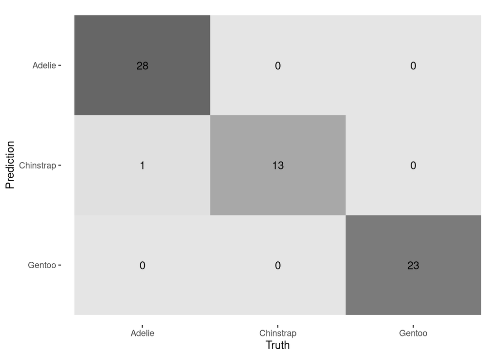

```r
as.data.frame(t_final$.predictions) %>%
yardstick::conf_mat(truth = species, estimate = .pred_class) %>%
  autoplot(type = "heatmap")
```

Разница в одно наблюдение, что не удивительно для такого маленького датасета.

Пингвины машут вам ручкой и говорят “Спасибо за внимание!”

Полезные ссылки: